# Analysis Walkthrough: working with the private or public PREDICTS database extract

Adriana De Palma

24 May, 2020

# Load the packages

Install some functions specifically developed for handling PREDICTS data.

```r
# install the PREDICTS yarg package

install.packages("yarg_0.1-14.tar.gz", repos = NULL, type = "source")

install.packages("glmmADMB", repos = "http://R-Forge.R-project.org")

install.packages("roquefort_0.1-2.tar.gz", repos = NULL, type = "source")
```

Load some packages for manipulating and modelling the data.

```r
library(yarg) # useful functions for dealing with PREDICTS data

library(roquefort) # useful PREDICTS functions, particularly for plotting

library(raster) # for dealing with spatial data

library(dplyr) # for handy data manipulation functions

library(tidyr) # ditto

library(lme4) # for mixed effects models

library(car) # for getting anova tables with significance values

library(DHARMa) # for model criticism plots

library(MuMIn) # for checking explanatory power of mixed effects models
```

# Read in and process the diversity data

First, you need to read in the raw diversity data as exported from the PREDICTS database.

## If you’re working on a PREDICTS database extract

If you’re working with a raw extract from the PREDICTS database, it will have diversity and the date it was extracted in the name.

```r
diversity <- readRDS("data/diversity-2020-02-17-03-32-37.rds")
```

The next thing is correct for differences in sampling effort across sites within a single study. This rescales sampling effort for each study to have a maximum value of 1, and then divides any diversity measurements that are sensitive to sampling effort by this rescaled measure of relative effort.

```r
# now correct the sampling efforts

diversity <- yarg::CorrectSamplingEffort(diversity)
```

```
## Correcting 8546 missing sampling effort values

## Rescaling sampling effort

## Correcting 2873940 values for sensitivity to sampling effort
```

Next we’ll merge any sites that are within the same land-use type and that have identical coordinates, start and end dates.

```r
diversity <- yarg::MergeSites(diversity,

                              silent = TRUE,

                              merge.extra = "Wilderness_area")
```

Rename the `Predominant_habitat` column, since it’s not really “habitat” that we’re looking at. This will also keep things a little more consistent with the public version of the PREDICTS database.

```r
diversity <- rename(diversity,

                    Predominant_land_use = Predominant_habitat)
```

## If you’re working on the public release of the database

If you’re working with the 2016 public release of the database, it will look like this:

```r
diversity <- readRDS("data/database.rds")
```

To make sure the rest of the PREDICTS functions work nice and neatly, we’re going to move `Measurement` and `Effort_corrected_measurement` into the same thing and the same thing with `Sampling_effort` and `Rescaled_sampling_effort`.

```r
diversity <- mutate(diversity,

                    Measurement = Effort_corrected_measurement,

                    Sampling_effort = Rescaled_sampling_effort)
```

Next we’ll merge any sites that are within the same land-use type and that have identical coordinates, start and end dates.

```r
diversity <- yarg::MergeSites(diversity, silent = TRUE, public = TRUE)
```

# Calculate the diversity metrics

Now you can calculate site-level diversity metrics:

```r
sites <- diversity %>%



  # add Diversity_metric_is_valid column

  mutate(Diversity_metric_is_valid = TRUE) %>%



  # calculate SiteMetrics

  yarg::SiteMetrics(extra.cols = c("SSB", "SSBS", "Predominant_land_use")) %>%



  # calculate the total abundance within each study

  group_by(SS) %>%

  mutate(MaxAbundance = ifelse(Diversity_metric_type == "Abundance",

                               max(Total_abundance),

                               NA)) %>%

  ungroup() %>%



  # now calculate the rescaled abundance (abundance divided by the maximum within each study)

  mutate(RescaledAbundance = ifelse(Diversity_metric_type == "Abundance",

                                    Total_abundance/MaxAbundance,

                                    NA))
```

```
## Computing site metrics for 3644244 measurements

## The data contain 569 sources, 789 studies and 29122 sites

## TODO fix within-site uniqueness check

## Computing site-level values

## Computing total abundance

## Computing species richness

## Computing Simpson's diversity

## Computing Chao

## Computing Rarefied Species Richness

## Assembling site-level values
```

The extra.cols parameter is used to save columns from the original diversity data, not in the list of default columns, in the site-level data. For the modelling, you will at least need ‘SSB’ and ‘SSBS’, which are the block and site-within-block identifications, but you’ll probably want some other columns too.

If you want to add data from a map, and the map is small enough to load into R, you can do this using the `raster` package.

For example, let’s get some Human Population Density (HPD) data (I’ve downloaded these from here: https://sedac.ciesin.columbia.edu/data/collection/gpw-v4/sets/browse).

```r
hpd <- raster("data/gpw-v4-population-density-adjusted-to-2015-unwpp-country-totals-2005/gpw-v4-population-density-adjusted-to-2015-unwpp-country-totals_2005.tif")
```

Now let’s pull out the HPD values for the sites in the diversity database:

```r
# get the coordinates from the sites dataset

point_coords <- dplyr::select(sites, Longitude, Latitude)



# extract the HPD values for these coordinates

hpd_value <- raster::extract(hpd, point_coords)



# take a look at the data

head(hpd_value)
```

```
## [1] 15528.409     0.000  2139.781  4884.564 11162.799 15528.409
```

```r
# place these data into the sites dataframe, adding a column called hpd and a log-transformed hpd column

sites <- mutate(sites,

                hpd = hpd_value,

                loghpd = log(hpd + 1))
```

The `Predominant_land_use` column holds the land use categories. They often need some tidying up.

```r
sites <- sites %>%



  mutate(



    # collapse primary forest and non-forest together into primary vegetation as these aren't well distinguished

    Predominant_land_use = recode_factor(Predominant_land_use,

                                  "Primary forest" = "Primary",

                                  "Primary non-forest" = "Primary"),



    # indeterminate secondary veg and cannot decide get NA

    Predominant_land_use = na_if(Predominant_land_use, "Secondary vegetation (indeterminate age)"),

    Predominant_land_use = na_if(Predominant_land_use, "Cannot decide"),

    Use_intensity = na_if(Use_intensity, "Cannot decide"),



    # set reference levels

    Predominant_land_use = factor(Predominant_land_use),

    Predominant_land_use = relevel(Predominant_land_use, ref = "Primary"),

    Use_intensity = factor(Use_intensity),

    Use_intensity = relevel(Use_intensity, ref = "Minimal use")

  )





# take a look at the LandUse/Use intensity split

table(sites$Predominant_land_use, sites$Use_intensity)
```

```
##

##                                     Minimal use Light use Intense use

##   Primary                                  4032      2500         681

##   Young secondary vegetation                841       280         370

##   Intermediate secondary vegetation         614       510         103

##   Mature secondary vegetation               544       474          31

##   Plantation forest                         877      1560         481

##   Pasture                                  1553      2126        1378

##   Cropland                                  657      1243        1465

##   Urban                                     338       622         265
```

# Model site-level diversity

Adriana has a document on Analysis Tips, which goes through the different methods of model simplification. In the meantime, here are some key rules for backwards stepwise model simplification, which is a commonly-used method in ecology:

1. Check the data for collinearity. If explanatory variables are strongly correlated with one another, they can produce biased model estimates.
2. Make sure you start with the dataset that has complete.cases (example below), otherwise your dataset will change size throughout the simplification process.
3. Specify your starting (maximal) model and check the assumptions.
4. Start by simplifying your random effects. Make multiple models with different combinations of random effects (I prefer to look at all possible combinations), then use AIC to check which has the lowest value. This will be the best random effects structure. Note that these models should have the full fixed effects structure (it should be your maximal model).
5. Now simplify your fixed effects by removing the least significant, most complex terms first (so that’s interactions before main effects). Remember that if a term remains in the interaction, you can’t remove it from the main effects, even if the main effect isn’t significant.

## Step 1: collinearity

Ok, so let’s check whether any of the candidate explanatory variables are strongly correlated with one another. You can look at the linear correlations between variables (using `cor.test`) or correlations between continuous and categorical variables (using `aov`). However, we tend to have multiple categorical varialbes. A good alternative is to look at Generalized Variance Inflation Factors. You can use a function provided by the Zuur book.

```r
source("https://highstat.com/Books/Book2/HighstatLibV10.R")



corvif(sites[ , c("Predominant_land_use", "Use_intensity", "loghpd")])
```

```
##

##

## Variance inflation factors

##

##                          GVIF Df GVIF^(1/2Df)

## Predominant_land_use 1.462393  7     1.027520

## Use_intensity        1.184080  2     1.043146

## loghpd               1.319367  1     1.148637
```

There are different ‘rules of thumb’ about how high is too high when it comes to GVIFs. Under 3 is great and under 5 is ok. Some people also say under 10 is acceptable, but I think that’s a bit too high personally.

If collinearity is a problem, then you’ll need to consider which variables are most important to include and what ones can be dropped.

## Step 2: complete cases

Next, let’s make sure that every row of our dataset has known values for all of our explanatory variables.

```r
model_data <- drop_na(sites,

                      Total_abundance, Predominant_land_use, Use_intensity, loghpd)
```

We’ll start by modelling `Total_abundance`. The maximal model is the most complex model you want to test. There’s a limit to how complicated this can or should be. Think carefully about what variables you want to test and what variables you might need to control for, and think carefully about what interactions are likely to be important. Here we’ll include main effects of `LandUse`, `Use_intensity` and `logHPD`, along with interactions between `LandUse` and the other variables.

You also need to think about the response variable. Do you expect your response variable to have normal *errors*? If it is continuous, and can take any number (negative or positive, integer or decimal) then it might well be fine. You probably do need an error structure if:

1. The values are bounded. E.g, you can’t have an abundance less than zero, and you can’t have a probability of presence greater than one
2. You expect there to be more variation as the mean increases. E.g., if you measure 10 elephants, you’ll have much greater variation in body mass than if you measure 10 mice.

In some cases, you may be able to transform your data (e.g., `log(abundance + 1)`), but it’s generally better to use an error structure if it is possible (it won’t always be). Have a look in the R book for using different error structures.

Always check your model using *model criticism plots* (if you’re using mixed-effects models, take a look at the `DhARMA package`). These plots will show you whether you’ve treated your data appropriately. Or you can plot the *residuals* of your model yourself. Note that here you’re interested in the distrubution of the *errors* or *residuals* of your model - that is the assumption that needs to be tested. It doesn’t matter really what the distrubution of the raw data actually is.

If you’re using a poisson or binomial error structure, you’ll also need to check for *overdispersion*. There’s a function in the `StatisticalModels` package called `GLMEROverdispersion`. If it’s present in a mixed-effects model fit using `lme4`, you can account for it by adding in an observation-level random effect (i.e., a random effect where each row in the dataset gets a unique level). In other packages, you may be able to fit a `quasi` distribution (e.g. `family = quasipoisson`), where the dispersion is an extra parameter that is estimated from the model, rather than being an assumption.

If you’re analysing count data, you might also find that there are far too many zeros in your data than you’d expect given a poisson distribution. If this is the case, you will need to consider using a zero-inflated poisson distribution or a hurdle model. Neither of these are available in `lme4`; if you want to use `lme4`, you can use a ‘modified’ hurdle model by first modelling the probability of species occurrence and then modelling the abundance of species that are present.

First, let’s transform `RescaledAbundance`.

```r
model_data <- mutate(model_data,

                     logAbundance = log(RescaledAbundance + 1),

                     sqrtAbundance = sqrt(RescaledAbundance)

)
```

```r
m1 <- lmer(sqrtAbundance ~ Predominant_land_use + Use_intensity + loghpd +

             Predominant_land_use:Use_intensity +

             Predominant_land_use:loghpd +

             (1|SS) + (1|SSB), data = model_data)
```

## Step 4: Choose the random effects

To select the random-effects structure, we use the method recommended by (Zuur et al., 2009) of taking the most complex fixed-effects structure, including all interactions, that will be tested in the second stage of modelling, and use it to compare different random-effects structures.

Study identity is always included as a random intercept because of the differences in the diversity metrics that will be caused by the fundamental differences in methods, sampling effort etc. among different studies. We also tend to include block as a random intercept, to account for the spatial configuration of sites. We can also include random slopes within study, to allow the effects of explanatory variables to vary among studies. You may also wish you include Source as a random intercept.

```r
m2 <- lmer(sqrtAbundance ~ Predominant_land_use + Use_intensity + loghpd +

             Predominant_land_use:Use_intensity +

             Predominant_land_use:loghpd +

             (1+Predominant_land_use|SS) + (1|SSB), data = model_data)
m3 <- lmer(sqrtAbundance ~ Predominant_land_use + Use_intensity + loghpd +

             Predominant_land_use:Use_intensity +

             Predominant_land_use:loghpd +

             (1+Use_intensity|SS) + (1|SSB), data = model_data)



m4 <- lmer(sqrtAbundance ~ Predominant_land_use + Use_intensity + loghpd +

             Predominant_land_use:Use_intensity +

             Predominant_land_use:loghpd +

             (1+loghpd|SS) + (1|SSB), data = model_data)
# compare the models that converged using Akaike's Information Criterion (AIC)

AIC(m1, m2, m3, m4)
```

|  | df | AIC |
| --- | --- | --- |
| m1 | 35 | -8802.656 |
| m2 | 70 | -10646.927 |
| m3 | 40 | -9558.599 |
| m4 | 37 | -9011.467 |

[output not shown]

4 rows

The lowest AIC value is the *best* model of the bunch. In this case, `m2`. However, this model threw up a warning that suggests that the model is too complex. There are ways of improving the chances that the model converges, but we’re going to assume that the model still doesn’t converge after we’ve tried the fixes. So let’s go for the best model that *did* converge, which is `m3`. This has Study (`SS`) and Block (`SSB`) as random intercepts and a random slope of `Use_intensity`. This means that we’re allowing the effect of use intensity on abundance to vary among studies. We’re not going to go into detail about this here.

## Step 5: Choose the best fixed effects structure

Let’s assess the fixed effects in this model.

```r
# have a look at the significance of the terms

Anova(m3)
```

|  | Chisq | Df | Pr(>Chisq) |
| --- | --- | --- | --- |
| Predominant_land_use | 341.65648785 | 7 | 7.523573e-70 |
| Use_intensity | 16.27927160 | 2 | 2.917434e-04 |
| loghpd | 0.08721986 | 1 | 7.677417e-01 |
| Predominant_land_use:Use_intensity | 147.22371356 | 14 | 2.579311e-24 |
| Predominant_land_use:loghpd | 102.88608944 | 7 | 2.732190e-19 |

[output not shown]

5 rows

The `Predominant_land_use:Use_intensity` interaction is significant, so we can’t remove this term from the model. This means that even if the main effects (`LandUse` and `Use_intensity`) weren’t significant, we wouldn’t want to remove them from the model. The same is true for the `Predominant_land_use:loghpd` interaction. But let’s imagine it wasn’t significant. Let’s go through the model simplification process. We start with the most complicated, least significant effect and try to remove it from the model. In this case, it is `Predominant_land_use:loghpd`.

```r
m3.1 <- update(m3,~.- Predominant_land_use:loghpd)
```

Next, we will check if we’ve lost a significant amount of explanatory power by removing this interaction. If we have, we want to keep the more complex model. If we haven’t lost a significant amount of explanatory power, then we can keep this simpler model. The test we’ll use is a *likelihood ratio test* (LRT).

```r
anova(m3.1, m3)
```

```
## refitting model(s) with ML (instead of REML)
```

|  | Df | AIC | BIC | logLik | deviance | Chisq | Chi Df | Pr(>Chisq) |
| --- | --- | --- | --- | --- | --- | --- | --- | --- |
| m3.1 | 33 | -9702.981 | -9441.345 | 4884.491 | -9768.981 | NA | NA | NA |
| m3 | 40 | -9791.594 | -9474.459 | 4935.797 | -9871.594 | 102.6125 | 7 | 3.112305e-19 |

[output not shown]

2 rows

Note that the Likelihood Ratio Test refits the models with Maximimum Likelihood. This is best when testing different fixed effects, but when testing different random effects, the models should be fit using Restricted Maximum Likelihood (REML, the default option).

The LRT is significant, so by removing the interaction from the model, *we have lost a significant amount of explanatory power*. This means that we should keep the more complex model. If it wasn’t significant, we would go with the simpler model and look at the `Anova` table again and remove the next most complicated, least significant term and repeat the process until everything left in the model is significant (this is backwards stepwise model simplification). The remaining model is our *minimum adequate model*.

Now let’s look at the model estimates of our mimumum adequate model (which in our case is also our maximal model).

```r
summary(m3)
```

```
## Linear mixed model fit by REML ['lmerMod']

## Formula: sqrtAbundance ~ Predominant_land_use + Use_intensity + loghpd +

##     Predominant_land_use:Use_intensity + Predominant_land_use:loghpd +

##     (1 + Use_intensity | SS) + (1 | SSB)

##    Data: model_data

##

## REML criterion at convergence: -9638.6

##

## Scaled residuals:

##     Min      1Q  Median      3Q     Max

## -4.1166 -0.5928 -0.0554  0.5353  5.1554

##

## Random effects:

##  Groups   Name                     Variance Std.Dev. Corr

##  SSB      (Intercept)              0.00459  0.06775

##  SS       (Intercept)              0.03241  0.18004

##           Use_intensityLight use   0.01815  0.13474  -0.28

##           Use_intensityIntense use 0.02455  0.15668  -0.29  0.58

##  Residual                          0.03073  0.17529

## Number of obs: 20504, groups:  SSB, 4235; SS, 648

```

[output cut: 186 more lines]

```
## Predominant_land_useUrban:Use_intensityIntense use                              -3.472

## Predominant_land_useYoung secondary vegetation:loghpd                            1.236

## Predominant_land_useIntermediate secondary vegetation:loghpd                     2.291

## Predominant_land_useMature secondary vegetation:loghpd                          -3.126

## Predominant_land_usePlantation forest:loghpd                                     0.106

## Predominant_land_usePasture:loghpd                                               4.461

## Predominant_land_useCropland:loghpd                                             -4.621

## Predominant_land_useUrban:loghpd                                                -3.504
```

```
##

## Correlation matrix not shown by default, as p = 32 > 12.

## Use print(x, correlation=TRUE)  or

##     vcov(x)        if you need it
```

The *intercept* term is the first level of each factor in the model, so in this case, Minimally-used Primary vegetation. The other land-use terms are the *difference* between the intercept and that land use. So the (square root rescaled) abundance in minimally-used primary vegetation is0.6533844 and the in minimally-used pasture it is -0.0284824 lower. Meaning that the (square root rescaled) abundance in minimally-used pasture is 0.6533844 + -0.0284824 = 0.6249021.

Note that this is just *one* approach to choosing a model. There are different methods for model selection. There is also model averaging. See the `MuMIn` package for more details. Depending on the purpose of your model (explanation, prediction, hypothesis testing…), you may have good reasons for choosing one method over another.

# Plot the results

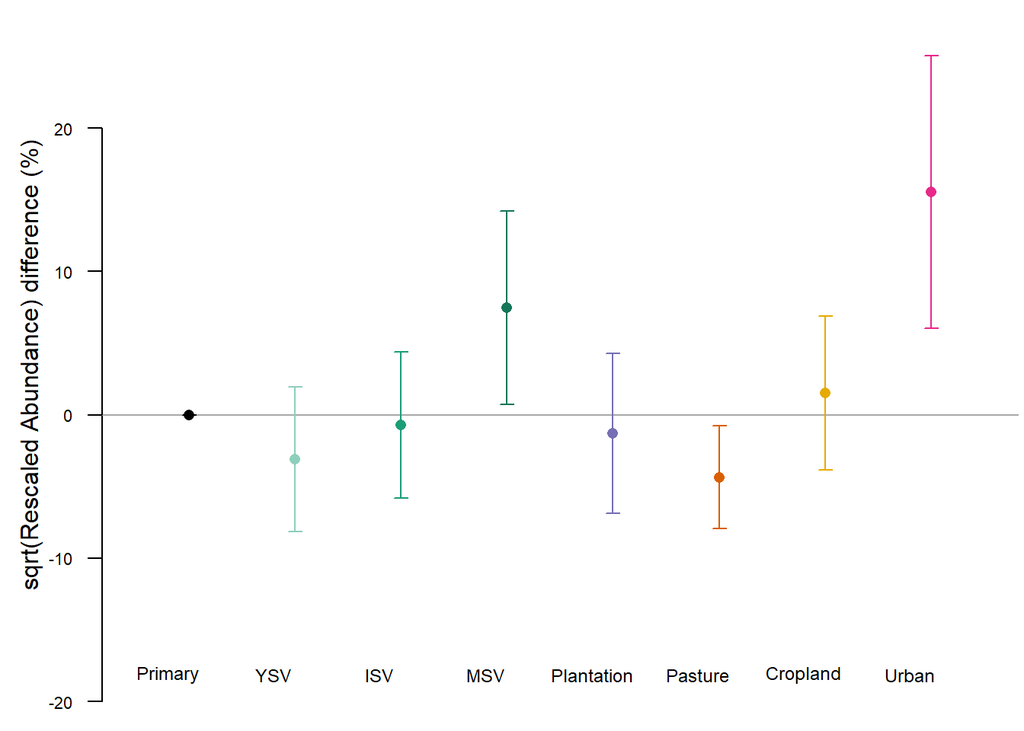

```r
roquefort::PlotErrBar(model = m3,

                      data = model_data,

                      responseVar = "sqrt(Rescaled Abundance)",

                      seMultiplier = 1.96,

                      secdAge = TRUE,

                      logLink = "n",

                      catEffects = c("Predominant_land_use"),

                      forPaper = TRUE,

                      plotLabels = FALSE)
```

Note that we usually collapse Land Use and Use intensity into a single factor - this makes plotting the results a little simpler, but it can make simplifying the model a little more complicated.